# Data Cleaning

Alexej Gossmann

July 12, 2016

### A. “Real Property Taxes” Dataset

Download the “real property taxes” dataset from the website (via OpenBaltimore), the data is located here (note you don't need to unzip it to read it into R): http://sisbid.github.io/Module1/data/real_property_tax.csv.gz

1. Read the Property Tax data into R and call it the variable `tax`

```r
tax <- read.csv("real_property_tax.csv.gz", na.string="")
dim(tax)
```

```
## [1] 238371      5
```

```r
head(tax)
```

```
##                     propertyAddress           lotSize cityTax stateTax
## 1 1205 CLARKSON ST                  0.018 ACRES         $0.00    $0.00
## 2 1207 CLARKSON ST                  0.018 ACRES         $0.00    $0.00
## 3 1209 CLARKSON ST                  0.018 ACRES         $0.00    $0.00
## 4 1203 CLARKSON ST                  0.018 ACRES         $0.00    $0.00
## 5 4111 OLD YORK ROAD                0.291 ACRES         $0.00    $0.00
## 6 101 W PRESTON ST                  0.909 ACRES         $0.00    $0.00
##                     resCode
## 1 NOT A PRINCIPAL RESIDENCE
## 2 NOT A PRINCIPAL RESIDENCE
## 3 NOT A PRINCIPAL RESIDENCE
## 4 NOT A PRINCIPAL RESIDENCE
## 5 NOT A PRINCIPAL RESIDENCE
## 6 NOT A PRINCIPAL RESIDENCE
```

```r
table(complete.cases(tax))
```

```
##
##  FALSE   TRUE
##  20548 217823
```

2. How many addresses pay property taxes?

```r
length(which(is.na(tax$cityTax)))
```

```
## [1] 20548
```

```r
length(which(is.na(tax$stateTax)))
```

```
## [1] 20347
```

```r
tax$cityTax <- as.numeric(gsub(pattern = "$", replacement = "",
                               tax$cityTax, fixed = TRUE))
tax$stateTax <- as.numeric(gsub(pattern = "$", replacement = "",
                                tax$stateTax, fixed = TRUE))
length(which(is.na(tax$cityTax)))
```

```
## [1] 20548
```

```r
length(which(is.na(tax$stateTax)))
```

```
## [1] 20347
```

```r
print("Num. properties paying city taxes:")
```

```
## [1] "Num. properties paying city taxes:"
```

```r
length(which(tax$cityTax > 0))
```

```
## [1] 217751
```

```r
print("Num. properties paying state taxes:")
```

```
## [1] "Num. properties paying state taxes:"
```

```r
length(which(tax$stateTax > 0))
```

```
## [1] 217952
```

3. What is the total city and state tax paid?

```r
paste("Total city:", sum(tax$cityTax, na.rm=TRUE), "$")
```

```
## [1] "Total city: 782158186.44 $"
```

```r
paste("Total state:", sum(tax$stateTax, na.rm=TRUE), "$")
```

```
## [1] "Total state: 39584834.09 $"
```

4. How many observations/properties are in each residence code?

```r
table(tax$resCode)
```

```
##
## NOT A PRINCIPAL RESIDENCE PRINCIPAL RESIDENCE
##                    122675                    115696
```

5. What is the 75th percentile of city and state tax paid by residence code?

```r
quantile(tax$cityTax, 0.75, na.rm=TRUE)
```

```
##     75%
## 3394.48
```

```r
quantile(tax$stateTax, 0.75, na.rm=TRUE)
```

```
##    75%
## 169.12
```

6. Subset the data to only retain those houses that are principal residences and describe the distribution of property taxes on these residences.

```r
library(stringr)
tax$resCode <- str_trim(tax$resCode)
principal.residence <- tax[tax$resCode == "PRINCIPAL RESIDENCE", ]
summary(principal.residence$cityTax)
```

```
##      Min.   1st Qu.    Median      Mean   3rd Qu.      Max.      NA's
##      2.25   1976.00   2752.00   3268.00   3770.00 233200.00       438
```

```r
summary(principal.residence$stateTax)
```

```
##     Min.  1st Qu.   Median     Mean  3rd Qu.     Max.     NA's
##     0.11    98.45   137.10   162.80   187.80 11620.00      438
```

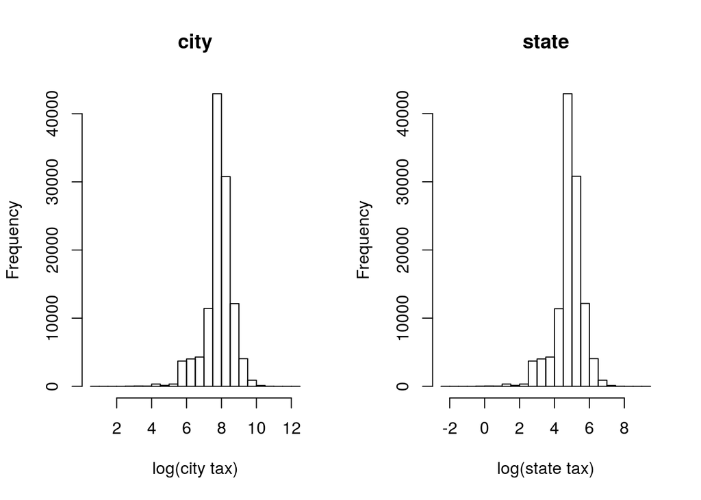

```r
par(mfrow=c(1,2))
hist(log(principal.residence$cityTax), xlab = "log(city tax)", main = "city")
hist(log(principal.residence$stateTax), xlab = "log(state tax)", main = "state")
```

7. Convert the ‘lotSize’ variable to a numeric square feet variable. Tips:
- Look at the data
- Assume hyphens represent inches within square foot meassuremnts
- Assume decimals within acreage measurements
- 1 acre = 43560 square feet
- Look at the data

```r
tax$lotSize[99996:100000]
```

```
## [1] 37-6X107-10       50X114-5          26-6X130          48X105
## [5] 16-4X103-6
## 60290 Levels:                   0.0016 ACRES      ...   X134
```

```r
x <- as.character(tax$lotSize)
x <- str_trim(x)
x[which(x == "")] <- NA
head(x)
```

```
## [1] "0.018 ACRES" "0.018 ACRES" "0.018 ACRES" "0.018 ACRES" "0.291 ACRES"
## [6] "0.909 ACRES"
```

```r
table(is.na(x))
```

```
##
##  FALSE   TRUE
## 238362      9
```

```r
x.converted <- rep(NA, length(x))
inacres <- grep(".*ACRES$", x = x)
y <- sapply(strsplit(x[inacres], split = " "), dplyr::first)
z <- as.numeric(y)
# This is taking too long now...
```

### B. “Baltimore Salary 2015” Dataset

Download the “Salary 2015” Dataset from the website (via OpenBaltimore), which is located here: http://sisbid.github.io/Module1/data//Baltimore_City_Employee_Salaries_FY2015.csv

8. Make an object called health.sal using the salaries data set, with only agencies of those with “fire” (or any forms), if any, in the name

```r
health.sal <- read.csv("Baltimore_City_Employee_Salaries_FY2015.csv", na.string="")
dim(health.sal)
```

```
## [1] 14017     7
```

```r
head(health.sal)
```

```
##                   name                      JobTitle AgencyID
## 1     Aaron,Patricia G Facilities/Office Services II   A03031
## 2        Aaron,Petra L    ASSISTANT STATE'S ATTORNEY   A29045
## 3   Abaineh,Yohannes T                EPIDEMIOLOGIST   A65026
## 4     Abbene,Anthony M                POLICE OFFICER   A99005
## 5       Abbey,Emmanuel         CONTRACT SERV SPEC II   A40001
## 6 Abbott-Cole,Michelle         CONTRACT SERV SPEC II   A90005
##                          Agency   HireDate AnnualSalary  GrossPay
## 1      OED-Employment Dev (031) 10/24/1979    $55314.00 $53626.04
## 2 States Attorneys Office (045) 09/25/2006    $74000.00 $73000.08
## 3  HLTH-Health Department (026) 07/23/2009    $64500.00 $64403.84
## 4       Police Department (005) 07/24/2013    $46309.00 $59620.16
## 5     M-R Info Technology (001) 05/01/2013    $60060.00 $54059.60
## 6           TRANS-Traffic (005) 11/28/2014    $42702.00 $20250.80
```

```r
table(complete.cases(health.sal)) # might be misleading due to coding of missing values
```

```
##
## FALSE  TRUE
##   279 13738
```

9. Make a data set called trans which contains only agencies that contain “TRANS”.

```r
x <- as.character(health.sal$Agency)
x <- str_trim(x)
containstrans <- grep("TRANS", x)
trans <- health.sal[containstrans, ]
head(trans)
```

```
##                    name                       JobTitle AgencyID
## 6  Abbott-Cole,Michelle          CONTRACT SERV SPEC II   A90005
## 21 Abendschein,Rosemary              OFFICE SUPERVISOR   A90002
## 34   Abual Gasim,Nada A                 CROSSING GUARD   C90786
## 37    Abu-Hakim,Kendall ELECTRICAL MECH ST LIGHTING II   A49390
## 43          Adabah,Fred                 STOREKEEPER II   A49320
## 59       Adams,Judith C                 CROSSING GUARD   C90786
##                         Agency   HireDate AnnualSalary  GrossPay
## 6          TRANS-Traffic (005) 11/28/2014    $42702.00 $20250.80
## 21         TRANS-Traffic (002) 07/19/1973    $48331.00 $54595.92
## 34 TRANS-Crossing Guards (786) 11/22/2004    $10546.00 $10594.83
## 37        TRANS-Highways (390) 01/09/2012    $35420.00 $70115.03
## 43        TRANS-Highways (320) 03/30/2015    $30834.00  $6907.73
## 59 TRANS-Crossing Guards (786) 06/02/1990    $11467.00 $11423.62
```

```r
dim(trans)
```

```
## [1] 1368    7
```

10. What is/are the profession(s) of people who have “abra” in their name for Baltimore’s Salaries?

```r
x <- as.character(health.sal$name)
x <- str_trim(x)
containsabra <- grep("abra", x)
health.sal$JobTitle[containsabra]
```

```
## factor(0)
## 1056 Levels: 911 LEAD OPERATOR 911 OPERATOR ... ZONING EXAMINER II
```

11. What is the distribution of annual salaries look like? What is the IQR?

```r
x <- as.character(health.sal$AnnualSalary)
x <- str_trim(x)
y <- as.numeric(gsub(pattern = "$", replacement = "", x, fixed = TRUE))
summary(y)
```

```
##    Min. 1st Qu.  Median    Mean 3rd Qu.    Max.
##     900   33350   48130   51710   68110  238800
```

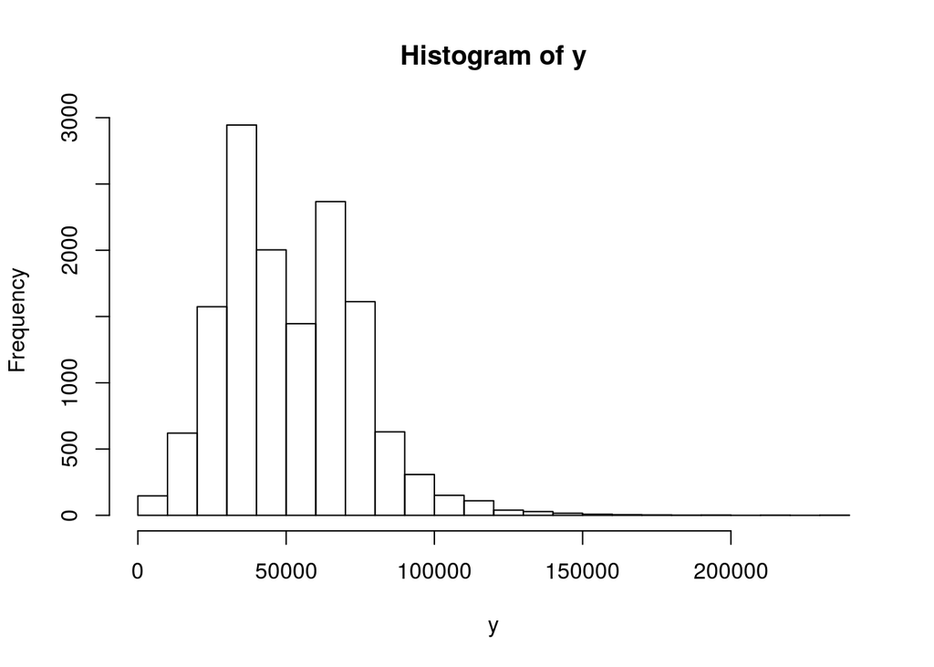

```r
hist(y, 20)
```

```r
health.sal$AnnualSalary <- y
```

12. Convert HireDate to the `Date` class - plot Annual Salary vs Hire Date

```r
library(lubridate)
x <- as.character(health.sal$HireDate)
newDate = mdy(x)
class(newDate)
```

```
## [1] "Date"
```

```r
head(newDate)
```

```
## [1] "1979-10-24" "2006-09-25" "2009-07-23" "2013-07-24" "2013-05-01"
## [6] "2014-11-28"
```

```r
health.sal$HireDate <- newDate
head(health.sal)
```

```
##                   name                      JobTitle AgencyID
## 1     Aaron,Patricia G Facilities/Office Services II   A03031
## 2        Aaron,Petra L    ASSISTANT STATE'S ATTORNEY   A29045
## 3   Abaineh,Yohannes T                EPIDEMIOLOGIST   A65026
## 4     Abbene,Anthony M                POLICE OFFICER   A99005
## 5       Abbey,Emmanuel         CONTRACT SERV SPEC II   A40001
## 6 Abbott-Cole,Michelle         CONTRACT SERV SPEC II   A90005
##                          Agency   HireDate AnnualSalary  GrossPay
## 1      OED-Employment Dev (031) 1979-10-24        55314 $53626.04
## 2 States Attorneys Office (045) 2006-09-25        74000 $73000.08
## 3  HLTH-Health Department (026) 2009-07-23        64500 $64403.84
## 4       Police Department (005) 2013-07-24        46309 $59620.16
## 5     M-R Info Technology (001) 2013-05-01        60060 $54059.60
## 6           TRANS-Traffic (005) 2014-11-28        42702 $20250.80
```

13. Plot annual salary versus hire date. Hint: first convert to numeric and date respectively

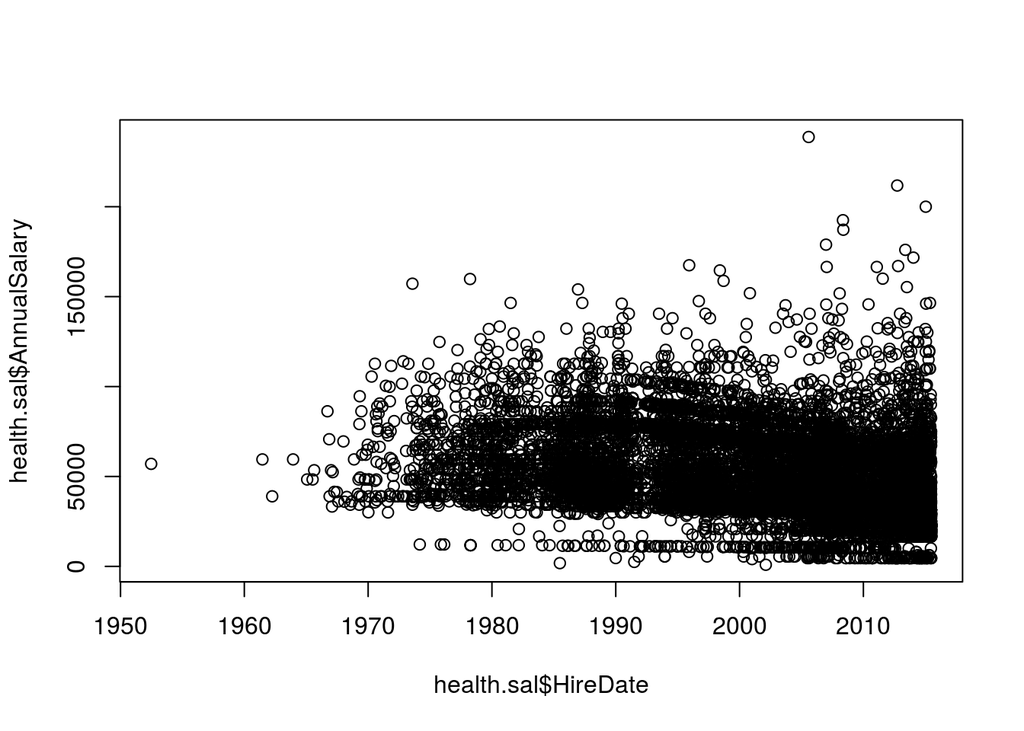

```r
plot(health.sal$HireDate, health.sal$AnnualSalary)
```

14. Create a smaller dataset that only includes the Police Department, Fire Department and Sheriff’s Office. How many employees are in this new dataset?

```r
x <- as.character(health.sal$Agency)
x <- str_trim(x)
#table(grep("Police", x, value=TRUE))
#table(grep("Sheriff", x, value=TRUE))
#table(grep("Fire", x, value=TRUE))
#ind <- c(grep("Police", x),
#         grep("Sheriff", x),
#         grep("Fire", x))
# better:
ind <- grep("fire|police|sheriff", x, ignore.case=TRUE)
length(ind)
```

```
## [1] 4922
```

```r
PFS <- health.sal[ind, ]
head(PFS)
```

```
##                   name                    JobTitle AgencyID
## 4     Abbene,Anthony M              POLICE OFFICER   A99005
## 7   Abdal-Rahim,Naim A EMT Firefighter Suppression   A64120
## 8       Abdi,Ezekiel W             POLICE SERGEANT   A99127
## 9  Abdul Adl,Attrice A    RADIO DISPATCHER SHERIFF   A38410
## 24  Abler II,Stanley C               PARAMEDIC CRT   A64465
## 29  Abrahams,Brandon A      POLICE OFFICER TRAINEE   A99416
##                     Agency   HireDate AnnualSalary   GrossPay
## 4  Police Department (005) 2013-07-24        46309  $59620.16
## 7    Fire Department (120) 2011-03-30        62175  $83757.48
## 8  Police Department (127) 2007-06-14        77343  $92574.91
## 9   Sheriff's Office (410) 1999-09-02        44548  $55943.29
## 24   Fire Department (465) 2006-03-20        65480 $104095.81
## 29 Police Department (416) 2015-01-20        46199  $18387.12
```

```r
dim(PFS)
```

```
## [1] 4922    7
```